# Global ABC Roadmap Development – Baseline Assessment

Cassandra Etter

2023-10-09

## R Markdown for UNOPS Buildings Data

Data for GlobalABC Project on construction and building indicators and projections This is the repository containing the source code and documentation for the Global ABC baseline assessment and indicators and projections for gap analysis. The point of the project is to 1) gain a good understanding of the context 2) identify challenges and opportunities and 3) measure the objective achievement gap.

The project was carried out by UNOPS.

###Import Necessary Packages

```r
library(readxl)
library(dplyr)
library(tidyverse)
library(devtools)
library(wbstats)
library(WDI)
library(readr)
library(remotes)
library(wpp2022)
```

```r
library(countrycode)
library(ggplot2)
library(fabletools)
library(fable)
library(tsibble)
library(tsibbledata)
library(lubridate)
library(devtools)
library(feasts)
library(googlesheets4)
library(data.table)
```

# Building Stock Floor area m2 baseline measurement

The goal is to build a floor area m2 per country using indicators for gdp*capita, household size, and population.

For GDP, I use World Bank API and pull GDP per capita, PPP (current international $) for 2020. For future updating, change this figure to the most recent available year.

##importing gdp per capita, PPP (current international $)

```r
gdp_per_capita <- wb_search("gdp.*capita")
gdp_per_capita <- wb_data("NY.GDP.PCAP.PP.CD", start_date = 2020, end_date = 2020)
```

For Population, I use World Bank data for base year 2020.

##importing population

```r
Population <- wb_search("population")
Population <- wb_data(indicator = "SP.POP.TOTL", start_date = 2020, end_date = 2020)
head(Population)
```

```
## # A tibble: 6 × 9
##   iso2c iso3c country    date SP.POP.TOTL unit  obs_status footnote last_updated
##   <chr> <chr> <chr>     <dbl>       <dbl> <chr> <chr>      <chr>    <date>
## 1 AW    ABW   Aruba      2020      106585 <NA>  <NA>       <NA>     2023-10-26
## 2 AF    AFG   Afghanis…  2020    38972230 <NA>  <NA>       <NA>     2023-10-26
## 3 AO    AGO   Angola     2020    33428486 <NA>  <NA>       <NA>     2023-10-26
## 4 AL    ALB   Albania    2020     2837849 <NA>  <NA>       <NA>     2023-10-26
## 5 AD    AND   Andorra    2020       77700 <NA>  <NA>       <NA>     2023-10-26
## 6 AE    ARE   United A…  2020     9287289 <NA>  <NA>       <NA>     2023-10-26
```

To retrieve average household size, I use UNDESA Data in baseyear 2020. As the data is survey based, some of the estimates in the dataset are from earlier years than 2020, in which case the most recent year is selected.

##importing average household size

```r
undesa_pd_2022_hh_size_composition <- read_excel("undesa_pd_2022_hh-size-composition.xlsx",
                                                 sheet = "HH size and composition 2022",
                                                 range = "A5:E1064")
average_household <- undesa_2022 <- read_excel("~/Documents/GlobalABC project/undesa_2022.xlsx",
                                               sheet = "HH size and composition 2022", range = "A5:E1064")
average_household <- as.data.frame(average_household)
average_household <- average_household%>%
        arrange(desc(`Reference date (dd/mm/yyyy)`)) %>%
        group_by(`ISO Code`) %>%
        filter(row_number()==1) %>%
        drop_na() %>%
        mutate(iso3c = countrycode(`Country or area`, "country.name", "iso3c"))
head(average_household)
```

```
## # A tibble: 6 × 6
## # Groups:   ISO Code [6]
##   `Country or area` `ISO Code` `Data source category` Reference date (dd/mm/yy…¹
##   <chr>                  <dbl> <chr>                                       <dbl>
## 1 Guinea                   324 DHS                                          2021
## 2 Latvia                   428 DYB                                          2021
## 3 Gambia                   270 DHS                                          2020
## 4 India                    356 DHS                                          2020
## 5 Kenya                    404 DHS                                          2020
## 6 Republic of Korea        410 DYB                                          2020
## # ℹ abbreviated name: ¹`Reference date (dd/mm/yyyy)`
## # ℹ 2 more variables: `Average household size (number of members)` <chr>,
## #   iso3c <chr>
```

This is a very messy dataset, and on review requires average household sizes be added for Botswana, Brunei, Bulgaria, China, French Polynesia, Iran, New Caledonia, Palau, Seychelles, St. Kitts, Trinidad and Tobago. I’ve checked national statistics websites to add missing variables. As there is also only one observation period for most countries, we are unable to projected trends in these figures. Moving forward, we will keep average household size constant, but assume that population growth will continue to expand number of households for projection purposes. ##adding missing data to average household size

```r
average_household$`Average household size (number of members)`[average_household$iso3c =="CHN"] <- 2.76
average_household$`Average household size (number of members)`[average_household$iso3c =="IRN"] <- 3.2
average_household$`Average household size (number of members)`[average_household$iso3c =="BWA"] <- 3.3
average_household$`Average household size (number of members)`[average_household$iso3c =="BRN"] <- 5
average_household$`Average household size (number of members)`[average_household$iso3c =="BGR"] <- 2.2
average_household$`Average household size (number of members)`[average_household$iso3c =="COK"] <- 4.4
average_household$`Average household size (number of members)`[average_household$iso3c =="KNA"] <- 3.7
average_household$`Average household size (number of members)`[average_household$iso3c =="TTO"] <- 3.2
average_household$`Average household size (number of members)`[average_household$iso3c =="CYM"] <- 2.4
average_household$`Average household size (number of members)`[average_household$iso3c =="SYC"] <- 3.7
average_household$`Average household size (number of members)`[average_household$iso3c =="SHN"] <- 2.38
average_household$`Average household size (number of members)`[average_household$iso3c =="PYF"] <- 2.3
average_household$`Average household size (number of members)`[average_household$iso3c =="NCL"] <- 3.2
average_household$`Average household size (number of members)`[average_household$iso3c =="PLW"] <- 2.9

average_household <- average_household %>%
        drop_na(iso3c)
average_household$`Average household size (number of members)`= as.numeric(average_household$`Average household size (number of members)`)

head(average_household)
```

```
## # A tibble: 6 × 6
## # Groups:   ISO Code [6]
##   `Country or area` `ISO Code` `Data source category` Reference date (dd/mm/yy…¹
##   <chr>                  <dbl> <chr>                                       <dbl>
## 1 Guinea                   324 DHS                                          2021
## 2 Latvia                   428 DYB                                          2021
## 3 Gambia                   270 DHS                                          2020
## 4 India                    356 DHS                                          2020
## 5 Kenya                    404 DHS                                          2020
## 6 Republic of Korea        410 DYB                                          2020
## # ℹ abbreviated name: ¹`Reference date (dd/mm/yyyy)`
## # ℹ 2 more variables: `Average household size (number of members)` <dbl>,
## #   iso3c <chr>
```

## Calculate Average Buildingstock baseline

With all data imported and cleaned, we can now merge data to estimate the average building stock baseline (m2) as an estimate of residential floor area (m2)

```r
merged_data <- average_household %>%
        full_join(Population, by = "iso3c") %>%
        full_join(gdp_per_capita, by = "iso3c") %>%
        select(c(1, 2, 6, 5, 10, 18))

building_stock_m2 <- merged_data %>%
        mutate(average_household_size = as.numeric(`Average household size (number of members)`)) %>%
        mutate(num_households = SP.POP.TOTL / average_household_size) %>%
        mutate(avg_m2_house = NY.GDP.PCAP.PP.CD / 1000) %>%
        mutate(total_building_stock_m2 = num_households * avg_m2_house)
```

##Check Data To review our estimate, we look at the EU Building Stock Observatory Data Online, which provides estimated building stock information for each EU country. We sub select Germany, Finland and Poland at random for comparison. EU Observatory Data for total: DEU listed as 5,395,110,000 m2 for 2020, FIN = 311,270,000 , POL = 1,412,210,000 EU Observatory Data for residential alone: DEU = 3,566,430,000 FIN is = 205,660,000 POL = 1,009,270,000 *Our estimate:* DEU 2,194,921,435 , FIN = 139,721,906 POL = 474,621,575

#Building Stock Projections to 2050

We now turn to projecting our building stock out to 2050. Rather than regressing estimates on temporal data for building stock, we assume clear relationship between building stock and population growth, economic growth, and other social factors. As such, we use existing “best in class” prediction data from World Bank and the UNFCCC modelling group responsible for the Shared Socioeconomic Pathways used the AR6 report. This allows us to predict building stock to 2050 while incorporating more precise predictions.

##calculate projection for population figures using world bank projections out to 2050 ##

```r
population_projection <- read_excel("~/Documents/GlobalABC project/WB_Population_Projections.xlsx")

Total_pop_2050 <- population_projection %>%
        filter(`Series Name` == 'Population, total') %>%
        gather(Year, Population, -`Country Name` &
                       - `Country Code` & - `Series Name` & -`Series Code`) %>%
        mutate(cool_year = str_sub(Year, 1, 4) %>%
                       str_c(., "-01-01") %>% as.Date() ) %>%
        mutate(yq = tsibble::yearquarter(cool_year))


Pop_2050 <- Total_pop_2050 %>%
        as_tsibble(key = c('Country Name', 'Population'),
                            index = 'yq')
Pop_2050$Population = as.numeric(Pop_2050$Population)
colnames(Pop_2050)[2]<- "iso3c"
Pop_2050 <- Pop_2050 %>%
        mutate(year = year(cool_year)) %>%
        select(`Country Name`, iso3c, Population, year)
```

###Calculate projection for GDP (PPP) ##

To find an estimate for predictions of GDP (PPP current international $) to 2050, we use IIASA’s SSP scenarios. SSPs estimate growth rate at 5 year intervals out to 2100. We derive a growth rate between the five year increments and providing an annual growth rate for our years of interest (2020-2050).

```r
ssp_scenarios <- read_excel("2023-11-19 - IIASA SSP scenarios.xlsx") %>% as.data.table %>%
        select( -Variable, -Model) %>%
        mutate(iso3c = countrycode(Region, "country.name", "iso3c")) %>%
        pivot_longer(cols = starts_with("2"), names_to = "year", values_to = "count") %>%
        mutate(year = as.integer(as.character(year))) %>%
        select(Scenario, iso3c, year, gdp_ppp = count ) %>%
        arrange(Scenario, iso3c, year) %>%
        mutate(growth_rate = (gdp_ppp / lag(gdp_ppp))^(1/5))

ssp_gdp <- CJ(scenario = unique(ssp_scenarios$Scenario), iso3c = unique(ssp_scenarios$iso3c), year = 2020:2050) %>%
        mutate(growth_year = (floor((year - 2020) / 5) + 1) * 5 + 2020,
               gdp_ppp_year = (floor((year - 2020) / 5)) * 5 + 2020) %>%
        left_join(ssp_scenarios %>% select(scenario = Scenario, iso3c, growth_year = year, growth_rate),
                  by = c("scenario", "iso3c", "growth_year")) %>%
        left_join(ssp_scenarios %>% select(scenario = Scenario, iso3c, gdp_ppp_year = year, gdp_ppp_5y = gdp_ppp),
                  by = c("scenario", "iso3c", "gdp_ppp_year")) %>%
        mutate(gdp_ppp = gdp_ppp_5y * (growth_rate) ^ (year - (growth_year - 5)))

head(ssp_gdp)
```

```
##                 scenario iso3c year growth_year gdp_ppp_year growth_rate
## 1: SSP1 - Review Phase 1   ABW 2020        2025         2020    1.053768
## 2: SSP1 - Review Phase 1   ABW 2021        2025         2020    1.053768
## 3: SSP1 - Review Phase 1   ABW 2022        2025         2020    1.053768
## 4: SSP1 - Review Phase 1   ABW 2023        2025         2020    1.053768
## 5: SSP1 - Review Phase 1   ABW 2024        2025         2020    1.053768
## 6: SSP1 - Review Phase 1   ABW 2025        2030         2025    1.017442
##    gdp_ppp_5y  gdp_ppp
## 1:   3.537075 3.537075
## 2:   3.537075 3.727256
## 3:   3.537075 3.927663
## 4:   3.537075 4.138845
## 5:   3.537075 4.361383
## 6:   4.595885 4.595885
```

###Take Scenario 2 as Baseline

This provides us with 5 different scenarios for how GDP could change out to 2050. IIASA and UNFCCC recommend using the “middle of road” scenario (Scenario 2) for those looking at a business as usual future world. As such, we take Scenario 2 GDP predictions for our estimates. We also change the unit of observation from billion USD/Yr to base USD/Yr to allow for easier comparison.

```r
ssp_gdp <- ssp_gdp %>%
        filter(scenario == "SSP2 - Review Phase 1") %>%
        mutate(GDP = gdp_ppp * 1000000000)

head(ssp_gdp)
```

```
##                 scenario iso3c year growth_year gdp_ppp_year growth_rate
## 1: SSP2 - Review Phase 1   ABW 2020        2025         2020    1.054334
## 2: SSP2 - Review Phase 1   ABW 2021        2025         2020    1.054334
## 3: SSP2 - Review Phase 1   ABW 2022        2025         2020    1.054334
## 4: SSP2 - Review Phase 1   ABW 2023        2025         2020    1.054334
## 5: SSP2 - Review Phase 1   ABW 2024        2025         2020    1.054334
## 6: SSP2 - Review Phase 1   ABW 2025        2030         2025    1.017387
##    gdp_ppp_5y  gdp_ppp        GDP
## 1:   3.537075 3.537075 3537075219
## 2:   3.537075 3.729260 3729260176
## 3:   3.537075 3.931887 3931887393
## 4:   3.537075 4.145524 4145524244
## 5:   3.537075 4.370769 4370768931
## 6:   4.608252 4.608252 4608252159
```

###check work with a graph for selected countries

To check our data we now select 5 countries at random from different continents and economic backgrounds (USA, Haiti, France, Kenya, and Japan). The figures appear to support general expected trends.

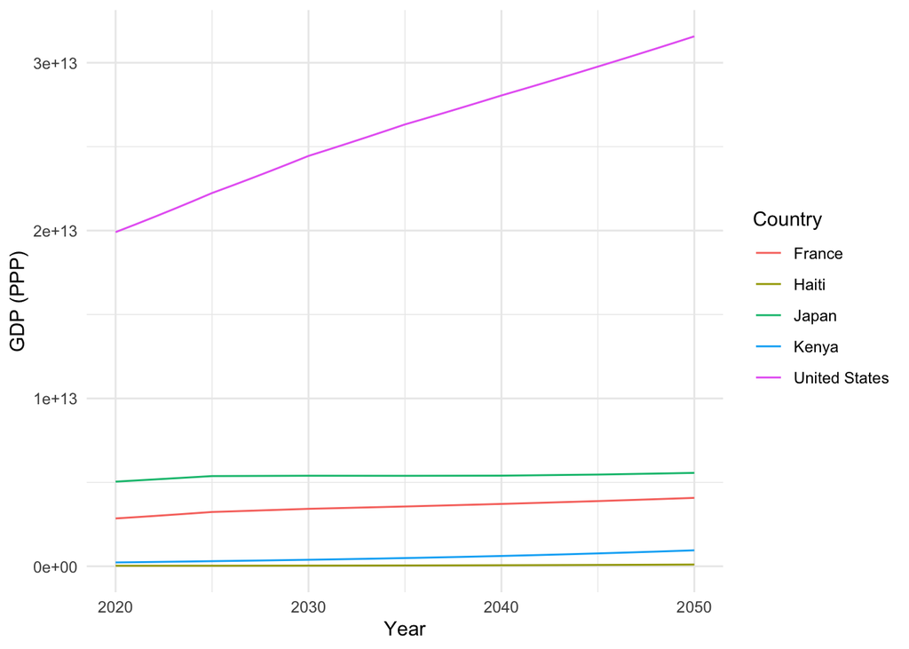

```r
selected_countries <- c("USA", "HTI", "FRA", "KEN", "JPN")

GDP_Filt_2050 <- ssp_gdp %>%
        filter( iso3c %in% selected_countries) %>%
        select(iso3c, year, GDP) %>%
        mutate(Country = countrycode(`iso3c`, "iso3c", "country.name")) %>%
        as.data.frame()

ggplot(GDP_Filt_2050, aes(x = year, y = GDP, color = Country)) +
        geom_line() +
        xlab("Year") + ylab("GDP (PPP)") +
        theme_minimal()
```

###Average Household Size to 2050 We make a decision here not to project household size forward due to lack of data. Instead, we will have the constant household size interact with population to still show change in number of households to allow for change in m2 but without the level of granularity of change in household size.

###Merge datasets to build figures necessary for floor space m2 to 2050 per country

```r
merged_2050 <- Pop_2050%>%
        left_join(average_household, by = c ("iso3c"))%>%
        select(c(`Country Name`, iso3c, Population, year, `Average household size (number of members)`))%>%
        drop_na(Population)

head (merged_2050)
```

```
## # A tibble: 6 × 5
##   `Country Name` iso3c Population  year Average household size (number of memb…¹
##   <chr>          <chr>      <dbl> <dbl>                                    <dbl>
## 1 Afghanistan    AFG     38972230  2020                                     8.04
## 2 Afghanistan    AFG     40099462  2021                                     8.04
## 3 Afghanistan    AFG     41128771  2022                                     8.04
## 4 Afghanistan    AFG     42239854  2023                                     8.04
## 5 Afghanistan    AFG     43372950  2024                                     8.04
## 6 Afghanistan    AFG     44515793  2025                                     8.04
## # ℹ abbreviated name: ¹`Average household size (number of members)`
```

### Add average household size for countries not included in UNESDA data set, but included in worldbank population projections

```r
###NA emerging from average household data being incomplete. Add 2.5 for all countries, unless known. Remove non - country regions.

merged_2050$`Average household size (number of members)`[merged_2050$iso3c =="SWE"] <- 2.15
merged_2050$`Average household size (number of members)`[merged_2050$iso3c =="ERI"] <- 5
merged_2050$`Average household size (number of members)`[merged_2050$iso3c =="SAU"] <- 5.2
merged_2050$`Average household size (number of members)`[merged_2050$iso3c =="ARE"] <- 4.9
merged_2050$`Average household size (number of members)`[merged_2050$iso3c =="ISL"] <- 2.5
merged_2050$`Average household size (number of members)`[merged_2050$iso3c =="DMA"] <- 3.2
merged_2050$`Average household size (number of members)`[merged_2050$iso3c =="LKA"] <- 3.7
merged_2050$`Average household size (number of members)`[merged_2050$iso3c =="VIR"] <- 2.14
merged_2050$`Average household size (number of members)`[merged_2050$iso3c =="LBY"] <- 5.6
merged_2050$`Average household size (number of members)`[merged_2050$iso3c =="LBN"] <- 4.07
merged_2050$`Average household size (number of members)`[merged_2050$iso3c =="KWT"] <- 5.5
merged_2050$`Average household size (number of members)`[merged_2050$iso3c =="VCT"] <- 3
merged_2050$`Average household size (number of members)`[merged_2050$iso3c =="SLB"] <- 5.5
merged_2050$`Average household size (number of members)`[merged_2050$iso3c =="SMR"] <- 2.29
merged_2050$`Average household size (number of members)`[merged_2050$iso3c =="MNP"] <- 3.26
merged_2050$`Average household size (number of members)`[merged_2050$iso3c =="NRU"] <- 6.15
merged_2050$`Average household size (number of members)`[merged_2050$iso3c =="FSM"] <- 6
merged_2050$`Average household size (number of members)`[merged_2050$iso3c =="MHL"] <- 6.8
merged_2050$`Average household size (number of members)`[merged_2050$iso3c =="XKX"] <- 5.5
merged_2050$`Average household size (number of members)`[merged_2050$iso3c =="GUM"] <- 3.44
merged_2050$`Average household size (number of members)`[merged_2050$iso3c =="GRD"] <- 4
merged_2050$`Average household size (number of members)`[merged_2050$iso3c =="GIB"] <- 2.18
merged_2050$`Average household size (number of members)`[merged_2050$iso3c =="FRO"] <- 2.85
merged_2050$`Average household size (number of members)`[merged_2050$iso3c =="DNK"] <- 2.1
merged_2050$`Average household size (number of members)`[merged_2050$iso3c =="CUW"] <- 2.7
merged_2050$`Average household size (number of members)`[merged_2050$iso3c =="CHI"] <- 3
merged_2050$`Average household size (number of members)`[merged_2050$iso3c =="CPV"] <- 4.98
merged_2050$`Average household size (number of members)`[merged_2050$iso3c =="VGB"] <- 2.59
merged_2050$`Average household size (number of members)`[merged_2050$iso3c =="BHR"] <- 5.9
merged_2050$`Average household size (number of members)`[merged_2050$iso3c =="ATG"] <- 3
merged_2050$`Average household size (number of members)`[merged_2050$iso3c =="AND"] <- 2
merged_2050$`Average household size (number of members)`[merged_2050$iso3c =="ASM"] <- 5.6
```

##Add in gdp figures data to merged projection dataset

```r
merged_2050_2 <- merged_2050 %>%
        drop_na(`Average household size (number of members)`) %>%
        left_join(ssp_gdp, by = c('iso3c', 'year')) %>%
        select(c(1,2, 3, 4, 5, 11, 12)) %>%
        drop_na('gdp_ppp')
head(merged_2050_2)
```

```
## # A tibble: 6 × 7
##   `Country Name` iso3c Population  year Average household size…¹ gdp_ppp     GDP
##   <chr>          <chr>      <dbl> <dbl>                    <dbl>   <dbl>   <dbl>
## 1 Afghanistan    AFG     38972230  2020                     8.04    75.4 7.54e10
## 2 Afghanistan    AFG     40099462  2021                     8.04    78.3 7.83e10
## 3 Afghanistan    AFG     41128771  2022                     8.04    81.3 8.13e10
## 4 Afghanistan    AFG     42239854  2023                     8.04    84.4 8.44e10
## 5 Afghanistan    AFG     43372950  2024                     8.04    87.6 8.76e10
## 6 Afghanistan    AFG     44515793  2025                     8.04    91.0 9.10e10
## # ℹ abbreviated name: ¹`Average household size (number of members)`
```

##calculate floor space estimate using projections data

```r
BS_2050 <- merged_2050_2 %>%
        mutate(average_household_size = as.numeric(`Average household size (number of members)`)) %>%
        mutate(num_households = Population/ average_household_size) %>%
        mutate(gdp_per_capita = GDP / Population) %>%
        mutate(avg_m2_house = gdp_per_capita / 1000) %>%
        mutate(residential_building_stock_m2 = num_households * avg_m2_house) %>%
        mutate(total_building_stock_m2 = residential_building_stock_m2 * 2 )

head(BS_2050)
```

```
## # A tibble: 6 × 13
##   `Country Name` iso3c Population  year Average household size…¹ gdp_ppp     GDP
##   <chr>          <chr>      <dbl> <dbl>                    <dbl>   <dbl>   <dbl>
## 1 Afghanistan    AFG     38972230  2020                     8.04    75.4 7.54e10
## 2 Afghanistan    AFG     40099462  2021                     8.04    78.3 7.83e10
## 3 Afghanistan    AFG     41128771  2022                     8.04    81.3 8.13e10
## 4 Afghanistan    AFG     42239854  2023                     8.04    84.4 8.44e10
## 5 Afghanistan    AFG     43372950  2024                     8.04    87.6 8.76e10
## 6 Afghanistan    AFG     44515793  2025                     8.04    91.0 9.10e10
## # ℹ abbreviated name: ¹`Average household size (number of members)`
## # ℹ 6 more variables: average_household_size <dbl>, num_households <dbl>,
## #   gdp_per_capita <dbl>, avg_m2_house <dbl>,
## #   residential_building_stock_m2 <dbl>, total_building_stock_m2 <dbl>
```